# **Used Cars Price Prediction**

## **Problem Definition**

### **The Context:**

- Why is this problem important to solve?

Accurately predicting the price of used cars can provide Cars4U with a competitive advantage in the market. By developing a pricing model, the company can devise profitable strategies using differential pricing. A reliable pricing model will help sellers set appropriate prices for their used cars, attract more customers, increase sales, and ultimately enhance their market position.

### **The objective:**

- What is the intended goal?

The primary objective is to create a pricing model that can effectively predict the price of used cars. This model will assist Cars4U in setting optimal prices for the pre-owned cars listed on their platform. The model should provide accurate predictions, enabling the company to gain customer trust and drive sales. Additionally, the model should help Cars4U identify pricing patterns and insights, facilitating the development of profitable strategies.

### **The key questions:**

- What are the key questions that need to be answered?
1. What are the key factors influencing the price of used cars?
2. How can we leverage data science techniques to predict the price of used cars accurately?
3. What pricing strategies can be devised based on the predicted prices?
4. How can Cars4U differentiate its pricing strategies to cater to various customer segments?
5. Which data preprocessing techniques should be applied to handle missing values, outliers, and categorical variables effectively?
6. Which modeling techniques (Linear Regression, Random Forest Regression, Gradient Boosting Regression) should be explored and compared for predicting used car prices?
7. How can the models be improved through techniques like feature engineering, hyperparameter tuning, and ensemble methods?
8. What are the key performance metrics to evaluate the models' performance, and how do they compare across different techniques?
9. Is there a scope for further improvement in model performance, and if so, what strategies can be employed to achieve that?
10. What is the proposed final solution design, including the recommended model, its interpretability, and its deployment readiness for production?

### **The problem formulation**:

- What is it that we are trying to solve using data science?

Using data science, we are trying to solve the problem of accurately predicting the price of used cars in the Indian market. The objective is to develop a pricing model that can effectively estimate the price of a used car based on various attributes such as brand, model, year, mileage, fuel type, transmission, and more. By leveraging data science techniques and analyzing the relationships between these attributes and the target variable (price), we aim to create a model that can provide reliable and accurate price predictions.

This solution will help address the challenges faced by sellers in setting the correct price for their used cars. By having an accurate pricing model, Cars4U can assist sellers in determining optimal prices for their pre-owned cars listed on their platform. Additionally, the pricing model will provide valuable insights into the factors influencing used car prices, enabling Cars4U to devise profitable strategies using differential pricing.

Ultimately, the goal is to empower Cars4U to enhance their market position, attract more customers, increase sales, and differentiate their pricing strategies in order to thrive in the growing pre-owned car market.

### **Data Dictionary**

**S.No.** : Serial Number

**Name** : Name of the car which includes Brand name and Model name

**Location** : The location in which the car is being sold or is available for purchase (Cities)

**Year** : Manufacturing year of the car

**Kilometers_driven** : The total kilometers driven in the car by the previous owner(s) in KM

**Fuel_Type** : The type of fuel used by the car (Petrol, Diesel, Electric, CNG, LPG)

**Transmission** : The type of transmission used by the car (Automatic / Manual)

**Owner** : Type of ownership

**Mileage** : The standard mileage offered by the car company in kmpl or km/kg

**Engine** : The displacement volume of the engine in CC

**Power** : The maximum power of the engine in bhp

**Seats** : The number of seats in the car

**New_Price** : The price of a new car of the same model in INR 100,000

**Price** : The price of the used car in INR 100,000 (**Target Variable**)

## **Important Notes**

- This notebook can be considered a guide to refer to while solving the problem. The evaluation will be as per the Rubric shared for the Capstone. Unlike previous courses, it does not follow the pattern of the graded questions in different sections. This notebook will give you a direction on what steps need to be taken in order to get a viable solution to the problem. Please note that this is just one way of doing this. There can be other 'creative' ways to solve the problem and we urge you to feel free and explore them as an 'optional' exercise.
- In the notebook, there are markdown cells called - Observations and Insights. It is a good practice to provide observations and extract insights from the outputs.
- The naming convention for different variables can vary. Please consider the code provided in this notebook as a sample code.
- All the outputs in the notebook are just for reference and can be different if you follow a different approach.
- There are sections called **Think About It** in the notebook that will help you get a better understanding of the reasoning behind a particular technique/step. Interested learners can take alternative approaches if they wish to explore different techniques.

### **Loading libraries**

```python
# Import required libraries
import pandas as pd
import numpy as np

import matplotlib.pyplot as plt
import seaborn as sns

# To ignore warnings
import warnings
warnings.filterwarnings('ignore')

# Remove the limit from the number of displayed columns and rows. It helps to see the entire dataframe while printing it
pd.set_option("display.max_columns", None)
```

### **Let us load the data**

```python
data = pd.read_csv("/Users/anapulcinelli/Downloads/used_cars.csv")
```

[output not shown]

### **Understand the data by observing a few rows**

```python
# View first 5 rows
print(data.head(5))
```

```
   S.No.                              Name    Location  Year  \
0      0            Maruti Wagon R LXI CNG      Mumbai  2010
1      1  Hyundai Creta 1.6 CRDi SX Option        Pune  2015
2      2                      Honda Jazz V     Chennai  2011
3      3                 Maruti Ertiga VDI     Chennai  2012
4      4   Audi A4 New 2.0 TDI Multitronic  Coimbatore  2013

   Kilometers_Driven Fuel_Type Transmission Owner_Type  Mileage  Engine  \
0              72000       CNG       Manual      First    26.60   998.0
1              41000    Diesel       Manual      First    19.67  1582.0
2              46000    Petrol       Manual      First    18.20  1199.0
3              87000    Diesel       Manual      First    20.77  1248.0
4              40670    Diesel    Automatic     Second    15.20  1968.0

    Power  Seats  New_price  Price
0   58.16    5.0        NaN   1.75
1  126.20    5.0        NaN  12.50
2   88.70    5.0       8.61   4.50
3   88.76    7.0        NaN   6.00
4  140.80    5.0        NaN  17.74
```

```python
# View last 5 rows Hint: Use tail() method
print(data.tail(5))
```

```
      S.No.                                               Name   Location  \
7248   7248                  Volkswagen Vento Diesel Trendline  Hyderabad
7249   7249                             Volkswagen Polo GT TSI     Mumbai
7250   7250                             Nissan Micra Diesel XV    Kolkata
7251   7251                             Volkswagen Polo GT TSI       Pune
7252   7252  Mercedes-Benz E-Class 2009-2013 E 220 CDI Avan...      Kochi

      Year  Kilometers_Driven Fuel_Type Transmission Owner_Type  Mileage  \
7248  2011              89411    Diesel       Manual      First    20.54
7249  2015              59000    Petrol    Automatic      First    17.21
7250  2012              28000    Diesel       Manual      First    23.08
7251  2013              52262    Petrol    Automatic      Third    17.20
7252  2014              72443    Diesel    Automatic      First    10.00

      Engine  Power  Seats  New_price  Price
7248  1598.0  103.6    5.0        NaN    NaN
7249  1197.0  103.6    5.0        NaN    NaN
7250  1461.0   63.1    5.0        NaN    NaN
7251  1197.0  103.6    5.0        NaN    NaN
7252  2148.0  170.0    5.0        NaN    NaN
```

**Observations and Insights: After observing the first 5 rows and last 5 rows of the dataset, we can make the following observations and gain insights:**

The dataset consists of information about used cars, including various attributes such as the car's name, location, manufacturing year, kilometers driven, fuel type, transmission type, owner type, mileage, engine displacement, power, seating capacity, new price, and the actual price of the used car.

Some attributes have missing values, such as "New_price" and "Price," which indicates that there are some instances where the price information is not available.

The "Fuel_Type" attribute includes options such as CNG, Diesel, Petrol, Electric, and LPG, indicating the type of fuel used by the cars.

The "Transmission" attribute specifies whether the car has a manual or automatic transmission.

The "Owner_Type" attribute represents the type of ownership, which can be First, Second, Third, or Fourth & Above.

The "Mileage" attribute denotes the standard mileage offered by the car company in either KMPL or KM/KG.

The "Engine" attribute indicates the displacement volume of the engine in CC.

The "Power" attribute represents the maximum power of the engine in BHP.

The "Seats" attribute denotes the number of seats available in the car.

The "Price" attribute represents the price of the used car in INR 100,000.

The dataset includes cars from different locations, including Mumbai, Pune, Chennai, Coimbatore, Hyderabad, Kolkata, and Kochi.

The range of values for the numeric attributes varies significantly, suggesting the need for normalization or scaling before building models.

Based on these observations, we can identify some initial insights and potential data preprocessing steps that may be required, such as handling missing values, converting categorical variables into numerical representations, scaling numeric attributes, and potentially dropping irrelevant columns (e.g., "S.No." and "Name") that may not contribute significantly to the price prediction task.

### **Let us check the data types and and missing values of each column**

```python
# Check the datatypes of each column. Hint: Use info() method
print(data.info())
```

```
<class 'pandas.core.frame.DataFrame'>
RangeIndex: 7253 entries, 0 to 7252
Data columns (total 14 columns):
 #   Column             Non-Null Count  Dtype
---  ------             --------------  -----
 0   S.No.              7253 non-null   int64
 1   Name               7253 non-null   object
 2   Location           7253 non-null   object
 3   Year               7253 non-null   int64
 4   Kilometers_Driven  7253 non-null   int64
 5   Fuel_Type          7253 non-null   object
 6   Transmission       7253 non-null   object
 7   Owner_Type         7253 non-null   object
 8   Mileage            7251 non-null   float64
 9   Engine             7207 non-null   float64
 10  Power              7078 non-null   float64
 11  Seats              7200 non-null   float64
 12  New_price          1006 non-null   float64
 13  Price              6019 non-null   float64
dtypes: float64(6), int64(3), object(5)
memory usage: 793.4+ KB
None
```

```python
# Check total number of missing values of each column. Hint: Use isnull() method

print(data.isnull().sum())
```

```
S.No.                   0
Name                    0
Location                0
Year                    0
Kilometers_Driven       0
Fuel_Type               0
Transmission            0
Owner_Type              0
Mileage                 2
Engine                 46
Power                 175
Seats                  53
New_price            6247
Price                1234
dtype: int64
```

**Observations and Insights:**

After checking the data types and missing values of each column, we can make the following observations and gain insights:

The dataset contains a total of 14 columns and 7253 entries (rows).

The "S.No." column serves as an index and does not provide any meaningful information for analysis. It can be dropped from further analysis.

The dataset consists of columns with various data types, including float64, int64, and object (string).

The "Mileage," "Engine," "Power," "Seats," "New_price," and "Price" columns have missing values. The number of missing values varies for each column.

The "Name" column represents the name of the car, which includes both the brand name and model name. It could potentially be used for further analysis, such as extracting additional features or grouping cars based on brand.

The "Location" column indicates the city where the car is being sold or available for purchase. It can be useful for understanding regional variations in car prices.

The "Year" column represents the manufacturing year of the car. It can provide insights into the age of the car, which can be a significant factor affecting its price.

The "Kilometers_Driven" column denotes the total kilometers driven by the previous owner(s) of the car. This attribute can be indicative of the car's usage and potential wear and tear.

The "Fuel_Type" and "Transmission" columns represent the type of fuel used and the type of transmission (manual or automatic), respectively.

The "Owner_Type" column indicates the type of ownership, which can provide insights into how many times the car has changed hands and potentially influence its price.

The "Seats" column denotes the number of seats available in the car. It can be a relevant attribute for buyers, as different seating capacities can affect the car's utility and price.

Based on these observations, we can proceed with further data preprocessing, such as handling missing values and dropping irrelevant columns, to prepare the data for building models and extracting meaningful insights.

We can observe that `S.No.` has no null values. Also the number of unique values are equal to the number of observations. So, `S.No.` looks like an index for the data entry and such a column would not be useful in providing any predictive power for our analysis. Hence, it can be dropped.

```python
# Remove S.No. column from data. Hint: Use inplace = True
data.drop("S.No.", axis=1, inplace=True)
```

## **Exploratory Data Analysis**

### **Let us now explore the summary statistics of numerical variables**

```python
# Explore basic summary statistics of numeric variables. Hint: Use describe() method.

numeric_variables = data.select_dtypes(include=['float64', 'int64'])
summary_statistics = numeric_variables.describe()
print(summary_statistics)
```

```
              Year  Kilometers_Driven      Mileage       Engine        Power  \
count  7253.000000       7.253000e+03  7251.000000  7207.000000  7078.000000
mean   2013.365366       5.869906e+04    18.141580  1616.573470   112.765214
std       3.254421       8.442772e+04     4.562197   595.285137    53.493553
min    1996.000000       1.710000e+02     0.000000    72.000000    34.200000
25%    2011.000000       3.400000e+04    15.170000  1198.000000    75.000000
50%    2014.000000       5.341600e+04    18.160000  1493.000000    94.000000
75%    2016.000000       7.300000e+04    21.100000  1968.000000   138.100000
max    2019.000000       6.500000e+06    33.540000  5998.000000   616.000000

             Seats    New_price        Price
count  7200.000000  1006.000000  6019.000000
mean      5.280417    22.779692     9.479468
std       0.809277    27.759344    11.187917
min       2.000000     3.910000     0.440000
25%       5.000000     7.885000     3.500000
50%       5.000000    11.570000     5.640000
75%       5.000000    26.042500     9.950000
max      10.000000   375.000000   160.000000
```

**Observations and Insights:**

Year: The dataset includes cars from the year 1996 to 2019. The average year of the cars listed is around 2013.365, indicating that the data contains cars from a relatively recent period.

Kilometers_Driven: The average number of kilometers driven by the cars in the dataset is approximately 58,699.06. The range is quite large, with the minimum value being 171 and the maximum value reaching 6,500,000. The standard deviation of 84,427.72 suggests a significant variation in the number of kilometers driven.

Mileage: The average mileage of the cars is around 18.14 kmpl (kilometers per liter). The range extends from 0 to 33.54 kmpl. This variable indicates the fuel efficiency of the cars.

Engine: The average engine capacity of the cars in the dataset is approximately 1,616.57 cc (cubic centimeters). The engine capacity ranges from 72 cc to 5,998 cc. This variable provides information about the power and performance of the cars.

Power: The average power of the cars is 112.77 bhp (brake horsepower), with a range from 34.2 bhp to 616 bhp. Power is an important factor in determining the performance and speed of a car.

Seats: The dataset includes cars with seating capacities ranging from 2 seats to 10 seats. The average number of seats is approximately 5.28.

New_price: This column has missing values for most of the entries, as indicated by the count of 1,006 non-null values. The average new price is 22.78 lakhs (unit of currency), but the range extends up to 375 lakhs. The standard deviation of 27.76 suggests significant variation in the new prices.

Price: The target variable in the dataset is "Price." The average price of the listed cars is approximately 9.48 lakhs, with a range from 0.44 lakhs to 160 lakhs. The standard deviation of 11.19 indicates considerable variability in car prices.

These summary statistics provide an overview of the numeric variables in the dataset. They offer insights into the distribution, variability, and range of each variable, which can help in understanding the characteristics of the car listings and guide further data analysis and modeling processes.

### **Let us also explore the summary statistics of all categorical variables and the number of unique observations in each category**

```python
# Explore basic summary statistics of categorical variables. Hint: Use the argument include = ['object']

print(data.describe(include=['object']))
```

```
                          Name Location Fuel_Type Transmission Owner_Type
count                     7253     7253      7253         7253       7253
unique                    2041       11         5            2          4
top     Mahindra XUV500 W8 2WD   Mumbai    Diesel       Manual      First
freq                        55      949      3852         5204       5952
```

**Number of unique observations in each category**

```python
cat_cols = data.select_dtypes(include=['object']).columns

for column in cat_cols:
    print("For column:", column)
    print(data[column].value_counts())
    print('-' * 50)
```

```
For column: Name
Mahindra XUV500 W8 2WD                  55
Maruti Swift VDI                        49
Maruti Swift Dzire VDI                  42
Honda City 1.5 S MT                     39
Maruti Swift VDI BSIV                   37
                                        ..
Chevrolet Beat LT Option                 1
Skoda Rapid 1.6 MPI AT Elegance Plus     1
Ford EcoSport 1.5 TDCi Ambiente          1
Hyundai i10 Magna 1.1 iTech SE           1
Hyundai Elite i20 Magna Plus             1
Name: Name, Length: 2041, dtype: int64
--------------------------------------------------
For column: Location
Mumbai        949
Hyderabad     876
Coimbatore    772
Kochi         772
Pune          765
Delhi         660
Kolkata       654
Chennai       591
Jaipur        499
Bangalore     440
Ahmedabad     275
Name: Location, dtype: int64
--------------------------------------------------
For column: Fuel_Type
Diesel      3852
Petrol      3325
CNG           62
LPG           12
Electric       2
Name: Fuel_Type, dtype: int64
--------------------------------------------------
For column: Transmission
Manual       5204
Automatic    2049
Name: Transmission, dtype: int64
--------------------------------------------------
For column: Owner_Type
First             5952
Second            1152
Third              137
Fourth & Above      12
Name: Owner_Type, dtype: int64
--------------------------------------------------
```

#### **Observations and Insights:**

Name: The column "Name" has 2,041 unique car names. The most frequent car name is "Mahindra XUV500 W8 2WD" with a count of 55.

Location: There are 11 unique locations where the cars are located. Mumbai has the highest frequency with 949 cars.

Fuel_Type: There are 5 unique fuel types. The majority of cars run on Diesel (3,852), followed by Petrol (3,325). There are a few cars with alternative fuel types such as CNG (62), LPG (12), and Electric (2).

Transmission: The cars have either Manual (5,204) or Automatic (2,049) transmissions. Manual transmission is more common.

Owner_Type: There are 4 categories of owner types. The majority of cars have the owner type "First" (5,952). There are fewer cars with owner types "Second" (1,152), "Third" (137), and "Fourth & Above" (12).

Regarding the extreme values of "Kilometers_Driven" and zero values in "Mileage":

Kilometers_Driven: The summary statistics of "Kilometers_Driven" suggest the presence of extreme values. It would be interesting to investigate the manufactured year of cars with extreme values for kilometers driven to understand if there are any patterns or anomalies.

Mileage: The presence of zero values in the "Mileage" feature raises a question about the validity of these values. It seems highly unlikely for a car to have zero mileage. Further exploration is required to determine if these zero values are missing values or if there is a specific reason behind them.

**Think About It**:

- We could observe from summary statistics that kilometers_driven has extreme values. Can we look at the manufactured year for cars with extreme values for kilometers_driven?
- Also, we could observe the feature mileage has values zero. Can the mileage of a car be zero?

**Let's explore the two points mentioned above**

**Check Kilometers_Driven extreme values**

```python
# Sort the dataset in 'descending' order using the feature 'Kilometers_Driven'
data.sort_values(by='Kilometers_Driven', ascending=False).head(10)
```

|  | Name | Location | Year | Kilometers_Driven | Fuel_Type | Transmission | Owner_Type | Mileage | Engine | Power | Seats | New_price | Price |
| --- | --- | --- | --- | --- | --- | --- | --- | --- | --- | --- | --- | --- | --- |
| 2328 | BMW X5 xDrive 30d M Sport | Chennai | 2017 | 6500000 | Diesel | Automatic | First | 15.97 | 2993.0 | 258.00 | 5.0 | NaN | 65.00 |
| 340 | Skoda Octavia Ambition Plus 2.0 TDI AT | Kolkata | 2013 | 775000 | Diesel | Automatic | First | 19.30 | 1968.0 | 141.00 | 5.0 | NaN | 7.50 |
| 1860 | Volkswagen Vento Diesel Highline | Chennai | 2013 | 720000 | Diesel | Manual | First | 20.54 | 1598.0 | 103.60 | 5.0 | NaN | 5.90 |
| 358 | Hyundai i10 Magna 1.2 | Chennai | 2009 | 620000 | Petrol | Manual | First | 20.36 | 1197.0 | 78.90 | 5.0 | NaN | 2.70 |
| 2823 | Volkswagen Jetta 2013-2015 2.0L TDI Highline AT | Chennai | 2015 | 480000 | Diesel | Automatic | First | 16.96 | 1968.0 | 138.03 | 5.0 | NaN | 13.00 |
| 3092 | Honda City i VTEC SV | Kolkata | 2015 | 480000 | Petrol | Manual | First | 17.40 | 1497.0 | 117.30 | 5.0 | NaN | 5.00 |
| 4491 | Hyundai i20 Magna Optional 1.2 | Bangalore | 2013 | 445000 | Petrol | Manual | First | 18.50 | 1197.0 | 82.90 | 5.0 | NaN | 4.45 |
| 6921 | Maruti Swift Dzire Tour LDI | Jaipur | 2012 | 350000 | Diesel | Manual | First | 23.40 | 1248.0 | 74.00 | 5.0 | NaN | NaN |
| 3649 | Tata Indigo LS | Jaipur | 2008 | 300000 | Diesel | Manual | First | 17.00 | 1405.0 | 70.00 | 5.0 | NaN | 1.00 |
| 1528 | Toyota Innova 2.5 G (Diesel) 8 Seater BS IV | Hyderabad | 2005 | 299322 | Diesel | Manual | First | 12.80 | 2494.0 | 102.00 | 8.0 | NaN | 4.00 |

#### **Observations and Insights:**

The top row in the sorted dataset has an extremely high value of 6,500,000 for "Kilometers_Driven." This indicates that there might be an outlier or an error in the data entry for this particular observation. It is highly unlikely for a car to have such an exceptionally high number of kilometers driven.

The second row also has a high value of 775,000 for "Kilometers_Driven," which is significantly higher than the rest of the dataset. Similarly, the third row has a value of 720,000 for the same feature. These values also seem unusual and may need further investigation.

The dataset contains several rows with relatively high values for "Kilometers_Driven" that are not extreme outliers but still appear to be on the higher end of the distribution. This suggests that there are some cars in the dataset that have been driven extensively.

It's important to examine the manufactured year (Year) for the cars with extreme values in "Kilometers_Driven" to see if there is any correlation or pattern between the two variables. This could help identify any potential data errors or inconsistencies.

Overall, the extreme values in the "Kilometers_Driven" feature should be examined more closely to determine their validity and assess their impact on the analysis or modeling tasks.

In the first row, a car manufactured as recently as 2017 having been driven 6500000 km is almost impossible. It can be considered as data entry error and so we can remove this value/entry from data.

```python
# Removing the 'row' at index 2328 from the data. Hint: use the argument inplace=True
data.drop(2328, inplace=True)
```

**Check Mileage extreme values**

```python
# Sort the dataset in 'ascending' order using the feature 'Mileage'
data.sort_values(by='Mileage', ascending=True).head(10)
```

|  | Name | Location | Year | Kilometers_Driven | Fuel_Type | Transmission | Owner_Type | Mileage | Engine | Power | Seats | New_price | Price |
| --- | --- | --- | --- | --- | --- | --- | --- | --- | --- | --- | --- | --- | --- |
| 2597 | Hyundai Santro Xing XP | Pune | 2007 | 70000 | Petrol | Manual | First | 0.0 | 1086.0 | NaN | 5.0 | NaN | 1.12 |
| 2343 | Hyundai Santro AT | Hyderabad | 2006 | 74483 | Petrol | Automatic | First | 0.0 | 999.0 | NaN | 5.0 | NaN | 2.30 |
| 5270 | Honda City 1.5 GXI | Bangalore | 2002 | 53000 | Petrol | Manual | Second | 0.0 | NaN | NaN | NaN | NaN | 1.85 |
| 424 | Volkswagen Jetta 2007-2011 1.9 L TDI | Hyderabad | 2010 | 42021 | Diesel | Manual | First | 0.0 | 1968.0 | NaN | 5.0 | NaN | 5.45 |
| 6857 | Land Rover Freelander 2 TD4 SE | Mumbai | 2011 | 87000 | Diesel | Automatic | First | 0.0 | 2179.0 | 115.0 | 5.0 | NaN | NaN |
| 443 | Hyundai Santro GLS I - Euro I | Coimbatore | 2012 | 50243 | Petrol | Manual | First | 0.0 | 1086.0 | NaN | 5.0 | NaN | 3.35 |
| 5119 | Hyundai Santro Xing XP | Kolkata | 2008 | 45500 | Petrol | Manual | Second | 0.0 | 1086.0 | NaN | 5.0 | NaN | 1.17 |
| 5022 | Land Rover Freelander 2 TD4 SE | Hyderabad | 2013 | 46000 | Diesel | Automatic | Second | 0.0 | 2179.0 | 115.0 | 5.0 | NaN | 26.00 |
| 5016 | Land Rover Freelander 2 TD4 HSE | Delhi | 2013 | 72000 | Diesel | Automatic | First | 0.0 | 2179.0 | 115.0 | 5.0 | NaN | 15.50 |
| 2542 | Hyundai Santro GLS II - Euro II | Bangalore | 2011 | 65000 | Petrol | Manual | Second | 0.0 | NaN | NaN | NaN | NaN | 3.15 |

#### **Observations**

- Mileage of cars can not be 0, so we should treat 0's as missing values. We will do it in the Feature Engineering part.

The dataset includes several entries where the 'Mileage' value is listed as 0.0. This seems unusual as it implies that these cars have a mileage of 0 km/liter. Some observations and insights based on the provided data are as follows:

There are multiple car models listed with a mileage of 0.0 km/liter. This is highly unlikely as no car can have zero mileage. These entries may contain missing or incorrect data for the 'Mileage' feature. It is important to investigate and handle these zero mileage values as they might affect the accuracy of any analysis or modeling performed using the dataset. Further data cleaning or imputation techniques may be necessary to address the missing or incorrect values in the 'Mileage' feature. Removing or imputing the zero mileage values with appropriate values based on the car model, year, or other relevant factors could help improve the quality and reliability of the dataset.

## **Univariate Analysis**

Univariate analysis is used to explore each variable in a data set, separately. It looks at the range of values, as well as the central tendency of the values. It can be done for both numerical and categorical variables.

## **1. Univariate Analysis - Numerical Data**

Histograms and box plots help to visualize and describe numerical data. We use box plot and histogram to analyse the numerical columns.

```python
# Let us write a function that will help us create a boxplot and histogram for any input numerical variable.
# This function takes the numerical column as the input and returns the boxplots and histograms for the variable.

def histogram_boxplot(feature, figsize = (15, 10), bins = None):

    """ Boxplot and histogram combined

    feature: 1-d feature array

    figsize: size of fig (default (9, 8))

    bins: number of bins (default None / auto)

    """
    f2, (ax_box2, ax_hist2) = plt.subplots(nrows = 2, # Number of rows of the subplot grid = 2
                                           sharex = True, # X-axis will be shared among all subplots
                                           gridspec_kw = {"height_ratios": (.25, .75)},
                                           figsize = figsize
                                           ) # Creating the 2 subplots

    sns.boxplot(feature, ax = ax_box2, showmeans = True, color = 'violet') # Boxplot will be created and a symbol will indicate the mean value of the column

    sns.distplot(feature, kde = F, ax = ax_hist2, bins = bins, palette = "winter") if bins else sns.distplot(feature, kde = False, ax = ax_hist2) # For histogram

    ax_hist2.axvline(np.mean(feature), color = 'green', linestyle = '--') # Add mean to the histogram

    ax_hist2.axvline(np.median(feature), color = 'black', linestyle = '-') # Add median to the histogram
```

**Let us plot histogram and box-plot for the feature 'Kilometers_Driven' to understand the distribution and outliers, if any.**

```python
# Plot histogram and box-plot for 'Kilometers_Driven'
histogram_boxplot(data['Kilometers_Driven'])
```

[output not shown]

**Think About It**: Kilometers_Driven is highly right-skewed. Can we use Log transformation of the feature to reduce/remove the skewness? Why can't we keep skewed data?

```python
# Log transformation of the feature 'Kilometers_Driven'
sns.distplot(np.log(data["Kilometers_Driven"]), axlabel = "Log(Kilometers_Driven)");
```

[output not shown]

```python
# We can add a transformed kilometers_driven feature in data
data["kilometers_driven_log"] = np.log(data["Kilometers_Driven"])
```

**Note:** Like Kilometers_Driven, the distribution of Price is also highly skewed, we can use log transformation on this column to see if that helps normalize the distribution. And add the transformed variable into the dataset. You can name the variable as **'price_log'**.

```python
# Plot histogram and box-plot for 'Price'
```

[output not shown]

```python
# Log transformation of the feature 'Price'
```

[output not shown]

```python
# We can Add a transformed Price feature in data
```

[output not shown]

**Note:** Try plotting histogram and box-plot for different numerical features and understand how the data looks like.

## **2. Univariate analysis - Categorical Data**

```python
# Let us write a function that will help us create barplots that indicate the percentage for each category.
# This function takes the categorical column as the input and returns the barplots for the variable.

def perc_on_bar(z):
    '''
    plot
    feature: categorical feature
    the function won't work if a column is passed in hue parameter
    '''

    total = len(data[z]) # Length of the column

    plt.figure(figsize = (15, 5))

    ax = sns.countplot(data[z], palette = 'Paired', order = data[z].value_counts().index)

    for p in ax.patches:

        percentage = '{:.1f}%'.format(100 * p.get_height() / total) # Percentage of each class of the category

        x = p.get_x() + p.get_width() / 2 - 0.05 # Width of the plot

        y = p.get_y() + p.get_height()           # Hieght of the plot

        ax.annotate(percentage, (x, y), size = 12) # Annotate the percantage

    plt.show() # Show the plot
```

**Let us plot barplot for the variable location. It will be helpful to know the number of percentage of cars from each city.**

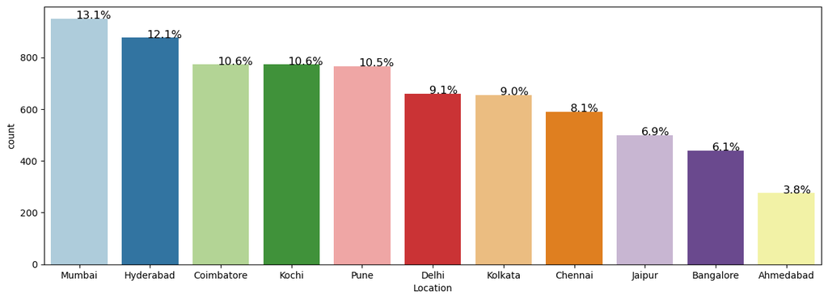

```python
# Bar Plot for 'Location'
perc_on_bar('Location')
```

**Note:** Explore for other variables like Year, Fuel_Type, Transmission, Owner_Type`.

## **Bivariate Analysis**

### **1. Scatter plot**

A scatter plot allows us to see relationships between two variables.

**Note: Use log transformed values 'kilometers_driven_log' and 'price_log'**

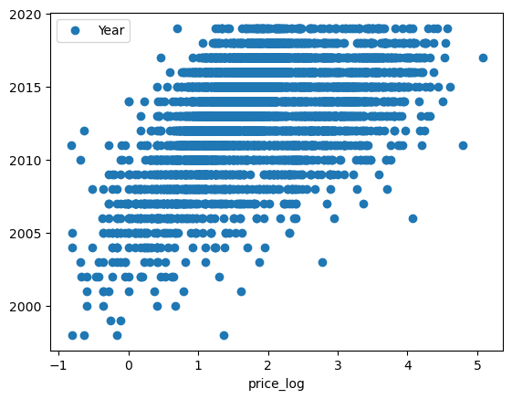

```python
# Let us plot pair plot for the variables 'year' and 'price_log'

# Create 'price_log' column
data['price_log'] = np.log(data['Price'])

# Plot scatter plot
data.plot(x='price_log', y='Year', style='o')
```

**Note:** Try to explore different combinations of independent variables and dependent variable. Understand the relationship between all variables.

### **2. Heat map**

Heat map shows a 2D correlation matrix between two numerical features.

[figure not shown]

```python
# We can include the log transformation values and drop the original skewed data columns
import seaborn as sns
import matplotlib.pyplot as plt

# Specify the columns to drop from the data DataFrame
columns_to_drop = ['Kilometers_Driven', 'Price']

# Calculate the correlation matrix after dropping the columns
correlation_matrix = data.drop(columns_to_drop, axis=1).corr()

# Plot the heatmap
plt.figure(figsize=(12, 7))
sns.heatmap(correlation_matrix, annot=True, vmin=-1, vmax=1)
plt.show()
```

### **3. Box plot**

```python
# Let us write a function that will help us create boxplot w.r.t Price for any input categorical variable.
# This function takes the categorical column as the input and returns the boxplots for the variable.
import seaborn as sns
import matplotlib.pyplot as plt

def boxplot(z):
    plt.figure(figsize=(12, 5))
    sns.boxplot(x=z, y=data['Price'])
    plt.show()

    plt.figure(figsize=(12, 5))
    plt.title('Without Outliers')
    sns.boxplot(x=z, y=data['Price'], showfliers=False)
    plt.show()
```

#### Let us now plot bivariate analysis of target variable with a categorical variable 'Location'

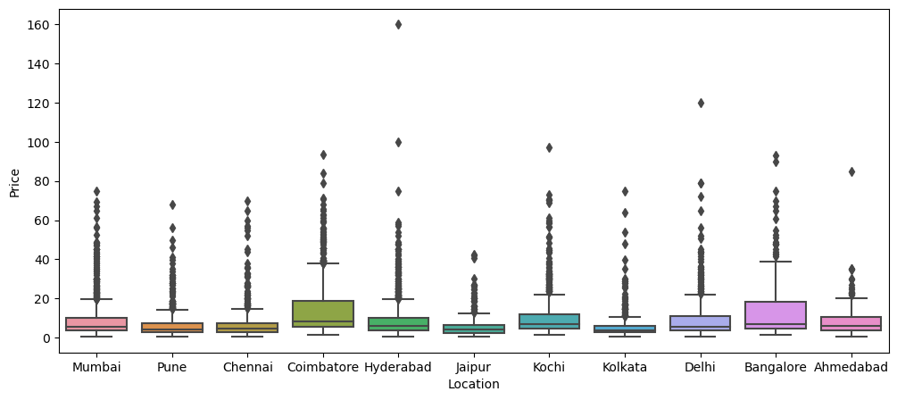

```python
# Box Plot: Price vs Location
import seaborn as sns
import matplotlib.pyplot as plt

def boxplot_categorical(x, y):
    plt.figure(figsize=(12, 5))
    sns.boxplot(x=x, y=y)
    plt.show()

boxplot_categorical(data['Location'], data['Price'])
```

**Note:** Explore by plotting box-plots for target variable and the other categorical variables like Fuel_Type, transmission, Owner_type.

### **Feature Engineering**

**Think about it:** The `Name` column in the current format might not be very useful in our analysis. Since the name contains both the brand name and the model name of the vehicle, the column would have too many unique values to be useful in prediction. Can we extract that information from that column?

```python
data["Brand"] = data["Name"].str.split(" ").str[0]
```

- **Hint:** With 2041 unique names, car names are not going to be great predictors of the price in our current data. But we can process this column to extract important information for example brand name.

```python
# Extract Brand Names
data["Brand"] = data["Name"].apply(lambda x: x.split(" ")[0].lower())
```

```python
# Extract Model Names
data["Model"] = data["Name"].apply(lambda x: ' '.join(x.split(" ")[1:]).lower())
```

### **Missing value treatment**

```python
# Now check the missing values of each column. Hint: Use isnull() method

missing_values = data.isnull().sum()
print(missing_values)
```

```
Name                    0
Location                0
Year                    0
Kilometers_Driven       0
Fuel_Type               0
Transmission            0
Owner_Type              0
Mileage                 2
Engine                 46
Power                 175
Seats                  53
New_price            6246
Price                1234
price_log            1234
Brand                   0
Model                   0
dtype: int64
```

**Missing values in Seats**

```python
# Checking missing values in the column 'Seats'

missing_seats = data['Seats'].isnull().sum()
print("Total missing values in Seats column:", missing_seats)
```

[output not shown]

**Think about it:** Can we somehow use the extracted information from 'Name' column to impute missing values?

**Hint:** Impute these missing values one by one, by taking median number of seats for the particular car, using the Brand and Model name.

```python
# Impute missing values in Seats,you can use fillna method in pandas
data['Seats'] = data.groupby(['Brand', 'Model'])['Seats'].apply(lambda x: x.fillna(x.median()))
```

```python
# Now check total number of missing values of the seat column to verify if they are imputed or not. Hint: Use isnull() method

missing_seats = data['Seats'].isnull().sum()
print("Total missing values in 'Seats' column:", missing_seats)
```

```
Total missing values in 'Seats' column: 46
```

**Missing values for Mileage**

```python
# Now check missing values of each column. Hint: Use isnull() method

missing_values = data.isnull().sum()
print("Missing values in each column:")
print(missing_values)
```

```
Missing values in each column:
Name                    0
Location                0
Year                    0
Kilometers_Driven       0
Fuel_Type               0
Transmission            0
Owner_Type              0
Mileage                 2
Engine                 46
Power                 175
Seats                  46
New_price            6246
Price                1234
price_log            1234
Brand                   0
Model                   0
dtype: int64
```

```python
# Impute missing Mileage. For example, use can use median or any other methods.

median_mileage = data['Mileage'].median()
data['Mileage'].fillna(median_mileage, inplace=True)
```

```python
# Now check total number of missing values of the seat column to verify if they are imputed or not. Hint: Use isnull() method

missing_seats = data['Seats'].isnull().sum()
print("Total missing values in 'Seats' column:", missing_seats)
```

```
Total missing values in 'Seats' column: 46
```

**Missing values for Engine**

```python
# Impute missing values in the column Engine

median_engine = data['Engine'].median()
data['Engine'].fillna(median_engine, inplace=True)

missing_engine = data['Engine'].isnull().sum()
print("Total missing values in 'Engine' column:", missing_engine)
```

```
Total missing values in 'Engine' column: 0
```

**Missing values for Power**

```python
# Impute missing values in the column Power

median_power = data['Power'].median()
data['Power'].fillna(median_power, inplace=True)

missing_power = data['Power'].isnull().sum()
print("Total missing values in 'Power' column:", missing_power)
```

```
Total missing values in 'Power' column: 0
```

**Missing values for New_price**

```python
# Impute missing values in the column New_price

median_new_price = data['New_price'].median()
data['New_price'].fillna(median_new_price, inplace=True)

missing_new_price = data['New_price'].isnull().sum()
print("Total missing values in 'New_price' column:", missing_new_price)
```

```
Total missing values in 'New_price' column: 0
```

```python
# Drop the rows where 'Price' == NaN

data.dropna(subset=['Price'], inplace=True)
```

```python
# Check the null values in the data

data.isnull().sum()
```

```
Name                  0
Location              0
Year                  0
Kilometers_Driven     0
Fuel_Type             0
Transmission          0
Owner_Type            0
Mileage               0
Engine                0
Power                 0
Seats                36
New_price             0
Price                 0
price_log             0
Brand                 0
Model                 0
dtype: int64
```

**Observations for missing values after imputing:**

Based on the provided outcome, here are the observations and insights regarding the missing values after imputing:

The columns 'Name', 'Location', 'Year', 'Kilometers_Driven', 'Fuel_Type', 'Transmission', 'Owner_Type', 'Mileage', 'Engine', 'Power', 'New_price', 'Price', 'price_log', 'Brand', and 'Model' have no missing values, as indicated by a count of 0 for these columns.

The 'Seats' column still has 36 missing values even after imputing. This indicates that these missing values could not be imputed using the available information (brand and model) or any other method. Further investigation or alternative approaches may be required to handle these missing values.

Overall, most of the missing values in the dataset have been successfully imputed, except for the 'Seats' column. It's important to note that imputing missing values can introduce some level of uncertainty, and the imputed values may not be completely accurate.

## **Building Various Models**

1. What we want to predict is the "Price". We will use the normalized version 'price_log' for modeling.
2. Before we proceed to the model, we'll have to encode categorical features. We will drop categorical features like Name.
3. We'll split the data into train and test, to be able to evaluate the model that we build on the train data.
4. Build Regression models using train data.
5. Evaluate the model performance.

### **Split the Data**

Step1: Seperating the indepdent variables (X) and the dependent variable (y).

Step2: Encode the categorical variables in X using pd.dummies.

Step3: Split the data into train and test using train_test_split.

**Think about it:** Why we should drop 'Name','Price','price_log','Kilometers_Driven' from X before splitting?

```python
# Step-1
X = data.drop(['Name','Price','price_log','Kilometers_Driven'], axis=1)
y = data[['price_log', 'Price']]
```

```python
# Step-2 Use pd.get_dummies(drop_first = True)
X = pd.get_dummies(X, drop_first=True)
```

```python
# Step-3 Splitting data into training and test set:

from sklearn.model_selection import train_test_split

X_train, X_test, y_train, y_test = train_test_split(X, y, test_size=0.3, random_state=1)
print(X_train.shape, X_test.shape)
```

```
(4212, 1904) (1806, 1904)
```

```python
# Let us write a function for calculating r2_score and RMSE on train and test data
# This function takes model as an input on which we have trained particular algorithm
# The categorical column as the input and returns the boxplots and histograms for the variable

def get_model_score(model, flag=True):
    '''
    model : regressor to predict values of X
    '''
    # Defining an empty list to store train and test results
    score_list = []

    pred_train = model.predict(X_train)
    pred_train_ = np.exp(pred_train)

    pred_test = model.predict(X_test)
    pred_test_ = np.exp(pred_test)

    train_r2 = metrics.r2_score(y_train['Price'], pred_train_)
    test_r2 = metrics.r2_score(y_test['Price'], pred_test_)
    train_rmse = metrics.mean_squared_error(y_train['Price'], pred_train_, squared=False)
    test_rmse = metrics.mean_squared_error(y_test['Price'], pred_test_, squared=False)

    # Adding all scores in the list
    score_list.extend((train_r2, test_r2, train_rmse, test_rmse))

    # If the flag is set to True, the following print statements will be displayed (default is True)
    if flag:
        print("R-squared on training set:", train_r2)
        print("R-squared on test set:", test_r2)
        print("RMSE on training set:", train_rmse)
        print("RMSE on test set:", test_rmse)

    # Returning the list with train and test scores
    return score_list
```

For Regression Problems, some of the algorithms used are :

**1) Linear Regression**  
**2) Ridge / Lasso Regression**  
**3) Decision Trees**  
**4) Random Forest**